# gss_cat — numeric relationships

Instructor demo · `geom_point` then `geom_line`

**Instructor.** Students should be driving this. Ask which plot / geom at each step. Cover at least `geom_point` and `geom_line`.

```r
library(tidyverse)
```

`gss_cat` is a sample from the US General Social Survey (NORC, University of Chicago). It lives in **forcats**, loaded with tidyverse.

```r
glimpse(gss_cat)
```

```
## Rows: 21,483
## Columns: 9
## $ year    <int> 2000, 2000, 2000, 2000, 2000, 2000, 2000, 2000, 2000, 2000, 20…
## $ marital <fct> Never married, Divorced, Widowed, Never married, Divorced, Mar…
## $ age     <int> 26, 48, 67, 39, 25, 25, 36, 44, 44, 47, 53, 52, 52, 51, 52, 40…
## $ race    <fct> White, White, White, White, White, White, White, White, White,…
## $ rincome <fct> $8000 to 9999, $8000 to 9999, Not applicable, Not applicable, …
## $ partyid <fct> "Ind,near rep", "Not str republican", "Independent", "Ind,near…
## $ relig   <fct> Protestant, Protestant, Protestant, Orthodox-christian, None, …
## $ denom   <fct> "Southern baptist", "Baptist-dk which", "No denomination", "No…
## $ tvhours <int> 12, NA, 2, 4, 1, NA, 3, NA, 0, 3, 2, NA, 1, NA, 1, 7, NA, 3, 3…
```

# 1. Age and TV hours

Two numeric variables: `age` and `tvhours`. We want the relationship.

**Ask:** recommended plot? They usually say scatterplot. Try it.

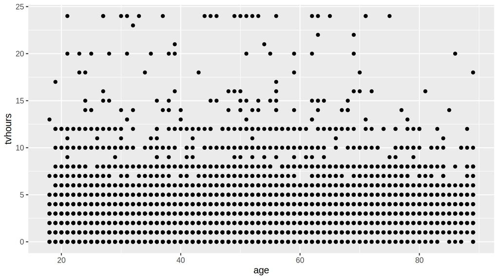

```r
ggplot(gss_cat, aes(x = age, y = tvhours)) +
  geom_point()
```

Too dense. Lots of overlap. **Ask:** argument to reduce transparency? `alpha`. Helps a bit.

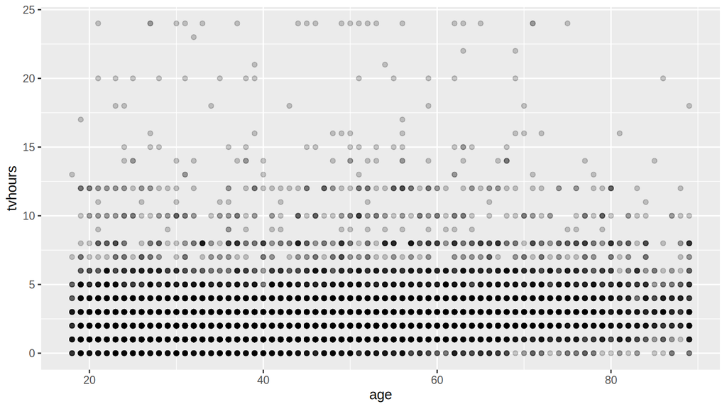

```r
ggplot(gss_cat, aes(x = age, y = tvhours)) +
  geom_point(alpha = 0.2)
```

Still busy. Drop `alpha` further.

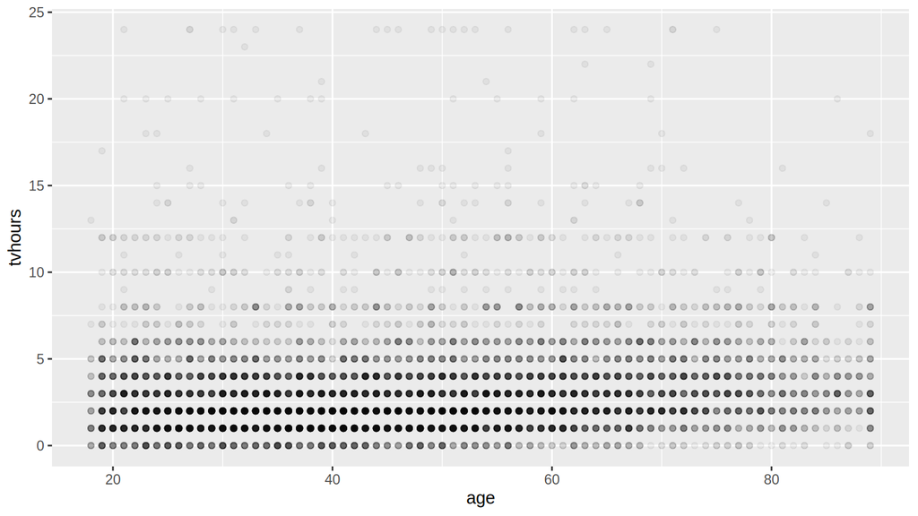

```r
ggplot(gss_cat, aes(x = age, y = tvhours)) +
  geom_point(alpha = 0.05)
```

Nice to add a trend line. **Ask:** which geom? They have seen `geom_smooth` by now.

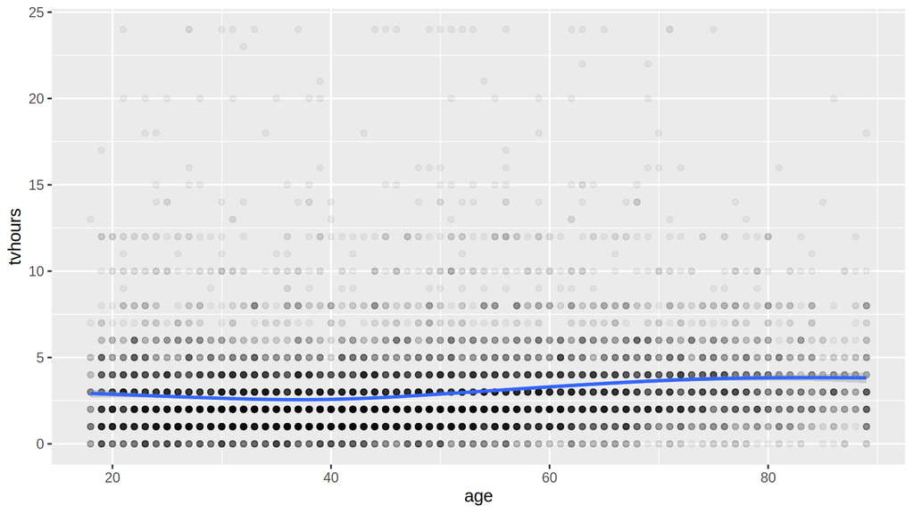

```r
ggplot(gss_cat, aes(x = age, y = tvhours)) +
  geom_point(alpha = 0.05) +
  geom_smooth()
```

Still a bit hard to read. **Maybe summarize first, then a line.** Group by age, mean TV hours, `geom_line`.

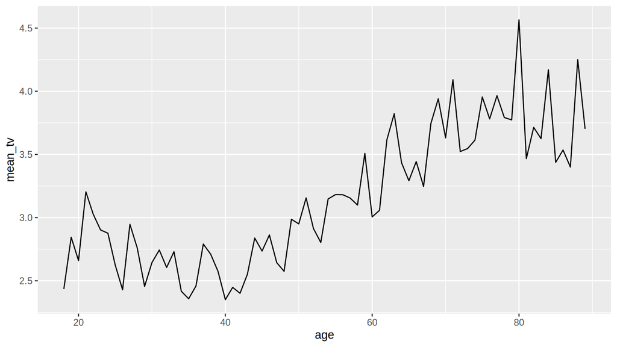

```r
gss_cat %>%
  group_by(age) %>%
  summarize(mean_tv = mean(tvhours, na.rm = TRUE)) %>%
  ggplot(aes(x = age, y = mean_tv)) +
  geom_line()
```

Better, but noisy: one mean per year of age, small n in the tails. **Bin into age groups**, same summarize + `geom_line`. (`group = 1` so the line connects the factor bins.)

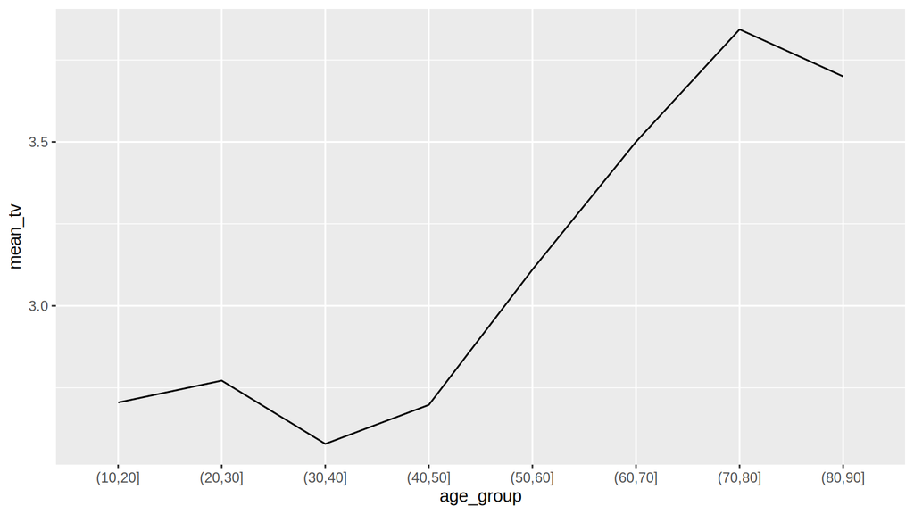

```r
gss_cat %>%
  mutate(age_group = cut(age, breaks = seq(10, 90, by = 10))) %>%
  group_by(age_group) %>%
  summarize(mean_tv = mean(tvhours, na.rm = TRUE)) %>%
  filter(!is.na(age_group)) %>%
  ggplot(aes(x = age_group, y = mean_tv, group = 1)) +
  geom_line()
```

Smoother. Still lots of data lost (spread, NAs, sample size). Win some, lose some.

# 2. Same pattern: race by year

Reuse group / summarize / `geom_line`. Optional slide task: number of people of each race surveyed per year. `count(year, race)` is the same idea.

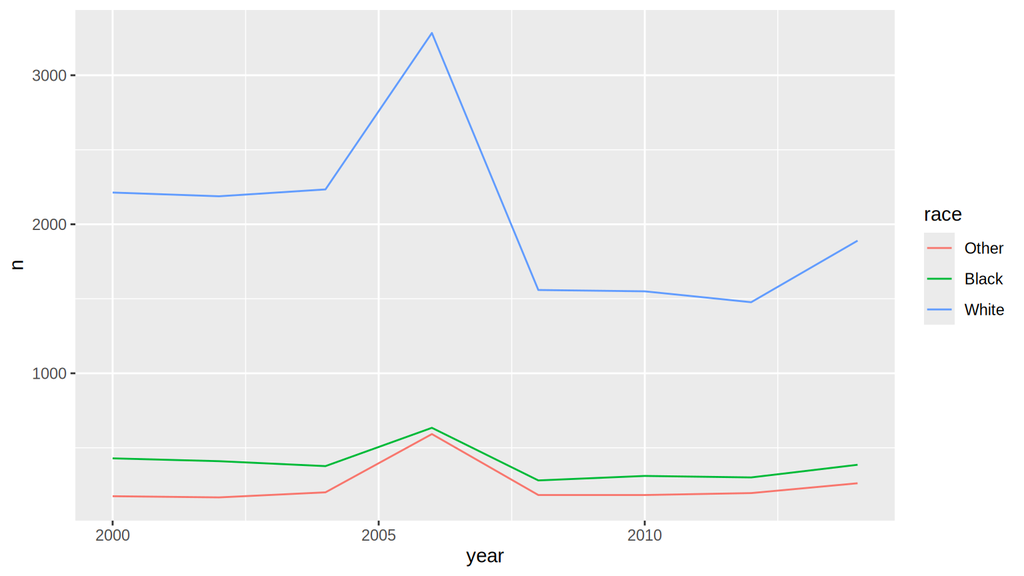

```r
gss_cat %>%
  count(year, race) %>%
  ggplot(aes(x = year, y = n, color = race)) +
  geom_line()
```